# 390 HW 3

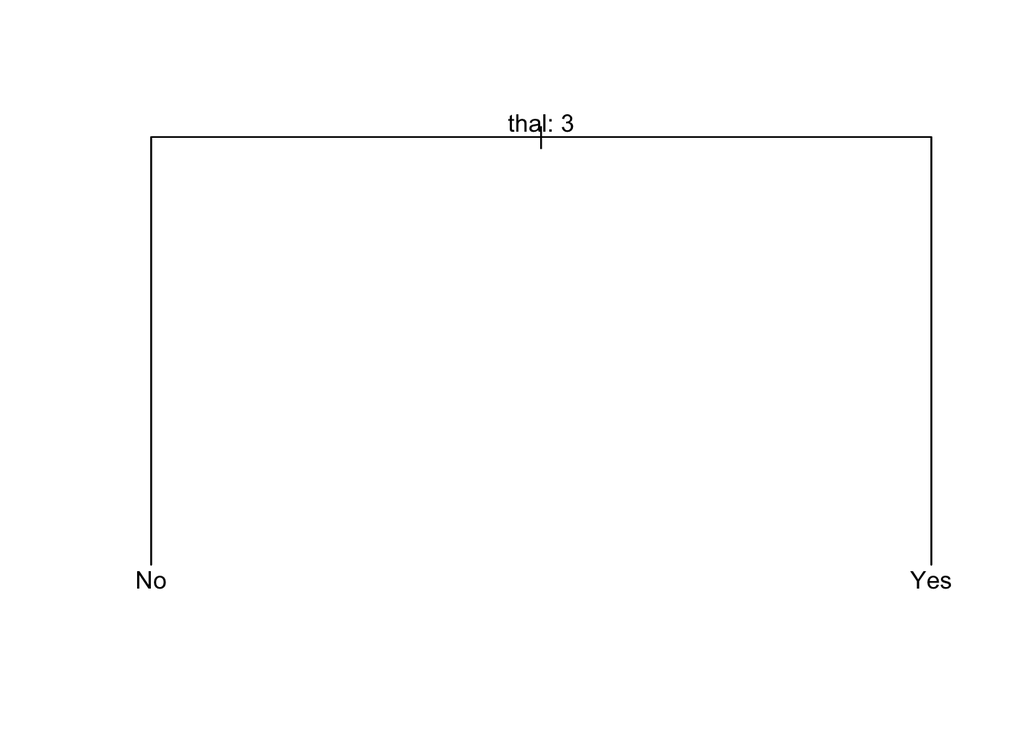

```r
set.seed(13)

# plotting pruned tree (2 terminal nodes)
prune.tree <- prune.misclass(tree.heart, best = 2)
plot(prune.tree)
text(prune.tree, pretty = 0)
```

```r
# predicting on testing set
tree.pred = predict(prune.tree, heart[-train,], type="class")
with(heart[-train,], table(tree.pred, hdisease))
```

```
##          hdisease
## tree.pred No Yes
##       No  28   9
##       Yes  8  12
```

```r
(28+12)/(28+12+9+8) # 70.18 accuracy
```

```
## [1] 0.7017544
```

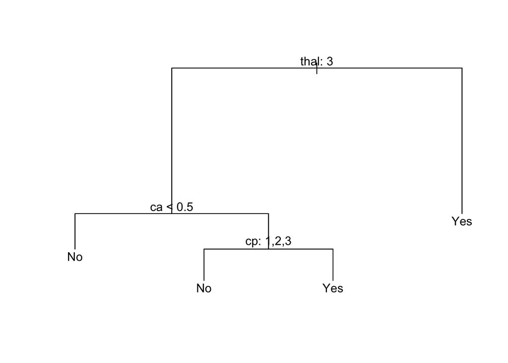

```r
# plotting pruned tree (4 terminal nodes)
prune.tree <- prune.misclass(tree.heart, best = 4)
plot(prune.tree)
text(prune.tree, pretty = 0)
```

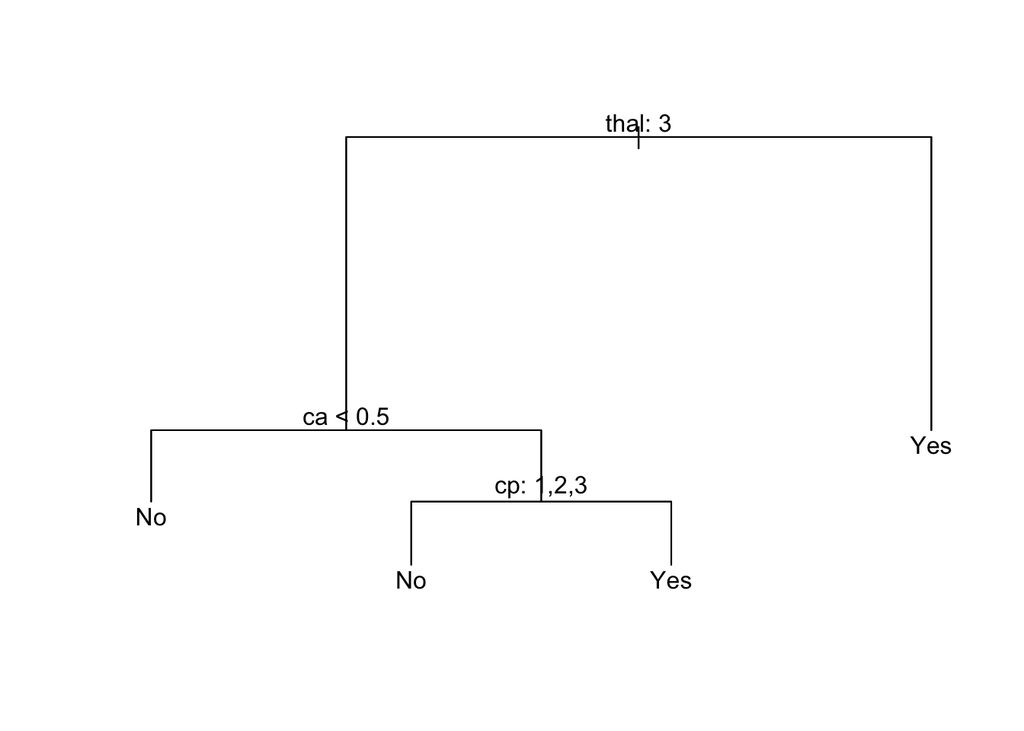

```r
# predicting on testing set (size 4)
prune.tree <- prune.misclass(tree.heart, best = 4)
plot(prune.tree)
text(prune.tree, pretty = 0)
```

```r
tree.pred = predict(prune.tree, heart[-train,], type="class")
with(heart[-train,], table(tree.pred, hdisease))
```

```
##          hdisease
## tree.pred No Yes
##       No  26   4
##       Yes 10  17
```

```r
(26+17)/(26+17+4+10) # 75.438% accuracy - increase from size 2 tree
```

```
## [1] 0.754386
```

**2.5** Discuss the trade-off in accuracy and interpretability in pruning the above tree.

We lose a non-trivial percentage of accuracy with a simpler tree. The full tree before pruning yields an accuracy rate of 80.7%, while the pruned tree with 4 terminal nodes has an accuracy rae of 75.438%. The pruned tree with only 2 terminal nodes has an accuracy rate of 70.18%, a 10% decrease from the full tree.

**2.6** Discuss the ways a decision tree could manifest algorithmic bias.

Overfitting with an overly complex decision tree and biased training data could manifest algorithmic bias.